# AMJ20211327_proof.pdf

Converted from PDF `Sajjadiani-HumanCapitalOutflows-2023-AMJ.pdf` · 26 pages · anchors: page `#pN`, block `#pN-bK`

Page 1

### WHO IS LEAVING AND WHY? THE DYNAMICS OF

### HIGH-QUALITY HUMAN CAPITAL OUTFLOWS

SIMA SAJJADIANI University of British Columbia

JOHN KAMMEYER-MUELLER

University of Minnesota

ALAN BENSON University of Minnesota

This study proposes a unified, dynamic framework based on turnover event theory to evaluate the effects of dismissals, layoff announcements, and voluntary turnover on subsequent work-unit voluntary turnover. Applying our approach to 1,620 retail stores over 22 months, we show that modeling exit events as a dynamic and interdependent system adds to our ability to predict subsequent human capital outflow. Dismissals had the weakest total effect on subsequent voluntary turnover, layoff announcements had the strongest and most immediate effects, and voluntary turnovers had moderate but lasting effects. We also find that these three exit reasons each exhibit a distinct pattern of subsequent turnover intensity and longevity. Based on characteristics of work units in our setting, our results correspond to a cumulative worker-level average effect of 0.17 quits following dismissals, 0.23 quits following quits, and 2.2 quits following a layoff. We find that these “multiplier” effects are concentrated among workers of similar performance: high performer exits beget high performer quits, just as low-performer exits beget lowperformer quits. Our findings suggest analyses offering individual-level estimates of turnover will generally underestimate the broader, work-unit level consequences of individual exit events on similar workers.

Exit events—including dismissals, layoffs, and voluntary turnover—change operational and social contexts in the workplace, prompting further human capital flows in the form of voluntary turnover (Laulie & Morgeson, 2021). For example, following voluntary turnover events, subsequent voluntary turnover can spread like a contagion (Felps, Mitchell, Hekman, Lee, Holtom, & Harman, 2009; Porter & Rigby, 2021). Layoff events can enhance feelings of job insecurity among those who remain, which results in higher subsequent voluntary turnover

throughout a work group (Friebel, Heinz, Weller, & Zubanov, 2021). Because voluntary turnover is costly and detrimental to unit performance (Porter & Rigby, 2021; Reilly, Nyberg, Maltarich, & Weller, 2014), researchers and practitioners seek to understand and manage the impact of employee exit events at the unit level (human capital outflows) on unit-level voluntary turnover. Previous studies have noted, however, that turnover is not a universally negative event for organizations with regard to the quality of the human capital being lost (Nyberg & Ployhart, 2013; Trevor & Piyanontalee, 2020). Given the key role that the quality of human capital outflow can play in the operational and social fabric of a work unit, exit events among high performers may have especially important consequences on subsequent unit-level voluntary turnover.

Despite considerable interest in work-unit dynamics and turnover, fundamental questions remain unanswered. For example, how do different types of departures relate to subsequent unit-level voluntary turnover? Do remaining members react differently if

This research was supported by an Insight Developmental Grant from the Canadian Social Sciences and Humanities Research Council (430-2019-00348). We are grateful to Gary Johns, Danielle van Jaarsveld, Antony Nyberg, Mark Maltarich, Michael Daniels, and Rebecca Paluch for their valuable feedback on earlier drafts of this manuscript. We would like to thank Ingo Weller and three anonymous reviewers for their helpful advice and guidance along the way. Also, we would like to thank our research assistant, Cheyenne Atwood, for her help.

1929

Copyright of the Academy of Management, all rights reserved. Contents may not be copied, emailed, posted to a listserv, or otherwise transmitted without the copyright holder's express written permission. Users may print, download, or email articles for individual use only.

r Academy of Management Journal 2023, Vol. 66, No. 6, 1929–1953. https://doi.org/10.5465/amj.2021.1327

Page 2

exits are voluntary quits, dismissals, or are the result of layoffs? Are subsequent voluntary turnover rates different depending on whether high or low performers exit? Finally, does exit among high/low performers have a disproportionate effect on exits among other high or low performers? Although prior work has established that turnover begets turnover (e.g., Heavey, Holwerda, & Hausknecht, 2013; Trevor & Nyberg, 2008), there is still a need for an integrative approach that encapsulates the endogenous, coevolving, and dynamic nature of exit events within the dynamic system of human capital flows. Such an approach can more accurately anticipate the dynamic consequences of turnover events given what it is known about each event.

To produce a model of voluntary turnover amenable to comparing the relative dynamic effects of exit events while considering the quality of the human capital outflow, we build upon the foundations laid by “turnover event theory” (TET) (Laulie & Morgeson, 2021). TET proposes that turnover events, depending on their strength, enact structural changes (i.e., alter job demands, resources, including human capital resources, and social relationships) and influence subsequent voluntary turnover. An event is “strong” according to the degree that it is novel (i.e., the extent to which events are uncommon or unexpected), disruptive (i.e., the extent to which events cause discontinuity and change routines), and critical (i.e., the extent to which events demand attention and influence valued outcomes). TET affords a dynamic perspective that underscores “the complexity of [turnover events] within organizations” and identifies key elements that contribute to the strength, magnitude, and duration of a particular event’s effects within the dynamic system of a work unit (Laulie & Morgeson, 2021: 18). We extend TET by comparing the dynamic effects of different exit events on subsequent unitlevel voluntary turnover. Our theory also provides an explanation of how the quality of human capital lost in each exit event changes the strength of the event and affects subsequent voluntary turnover rates in a dynamic system.

Our theoretical framework contributes to the turnover literature in a number of ways. First, we distinguish between and compare the effects of different types of turnover (dismissals, layoff announcements, and voluntary quits) on subsequent voluntary turnover. Second, we evaluate how the effects of turnover events vary depending on whether the instigating events involved the departure of high or low performers. Third, we treat human capital flow

as a dynamic system, whereby the effects of turnover may be small or large, immediate or delayed, or subject to “ripple” effects if subsequent turnover following an initial event begets turnover in and of itself. From these key features, we provide distinct predictions regarding the dynamic effects of turnover sensitive to differences in types of turnover and the quality of human capital. This approach responds to mounting evidence that exit events are best interpreted as constituent parts of a dynamic system (Call, Nyberg, Ployhart, & Weekley, 2015; Nyberg & Ployhart, 2013; Rubenstein, Eberly, Lee, & Mitchell, 2018). We further respond to calls for a systematic approach that evaluates the collective-level consequences of various exit events while taking into account the nuances of the disruption these events cause and the quality of the human capital outflows (Trevor & Piyanontalee, 2020).

Empirically, we study turnover dynamics using “panel vector autoregression” (PVAR). This method estimates the effect of a set of variables on the same set of variables in the future; for example, who turns over and why, given who turned over and why in the past. We implement these methods to examine human capital flows at 1,620 work units (stores) at a large national retailer over a 22-month period.

Our theory, analytical approach, and results lead us to a central claim:

Different types of employee exit events, in terms of turnover reasons and differences in the quality of human capital outflows, have varying implications for future voluntary turnover and the quality of the human capital associated with these subsequent outflows.

We hypothesize and demonstrate that, as antecedents of unit-level voluntary turnover, layoff announcements have comparatively large and immediate effects, voluntary turnovers have moderate but relatively long-lasting effects, and dismissals have relatively minor and fleeting effects.

Our study presents practitioners with an empirical method for understanding the distinctive organizational consequences of dismissals, layoff announcements, and quits. In our setting, we find the consequences of exits do not stop with the workers who depart, but, rather, exhibit a “multiplier” effect on overall unit-level voluntary turnover—particularly among workers of similar productivity. These multiplier effects suggest that organizations and researchers underestimate the true human capital costs of exit events if they disregard the interdependence of these events.

1930 Academy of Management Journal December

Page 3

THEORY AND HYPOTHESES

A core theme in TET is that exit events, depending on their levels of novelty, disruption, and criticality, can lead to various levels of structural changes related to job demands, resources (including human capital resources), and social relationships. These changes prompt stayers to make sense of the new situation and respond accordingly (Laulie & Morgeson, 2021). Following from these ideas, we derive predictions related to the direction and comparative magnitude of the effects of exit events on subsequent voluntary turnover rates. We also introduce the quality of human capital outflows as a moderator. As noted earlier, the quality of human capital outflows is central to both theory and practical implications for a great deal of turnover research. We provide a summary of the logic surrounding our hypotheses in Table 1.

Drawing on the TET framework, we expect that exit events can initiate a “disruption phase” in the work activities of a unit. A “recovery phase” occurs following a disruption phase (Hale, Ployhart, & Shepherd, 2016), during which organizations employ activities and procedures aimed at stabilizing job attitudes and obtaining the required knowledge to implement new routines. The team adaptability literature highlights the importance of time in the recovery process, as unit members dynamically learn how to adapt to a new context (Burke, Stagl, Klein, Goodwin, Salas, & Halpin, 2006; Hale et al., 2016; LePine, 2003). Although all exit events precipitate disruption and recovery, the magnitude and duration of their effects on job demands, resources, and social relationships vary based on the strength of the event (i.e., the extent of their novelty, disruption, and criticality). These structural changes, in turn, will affect subsequent unit-level voluntary turnover. The proportion of the unit affected by the exit event is another important factor that influences the event’s strength (Hausknecht & Holwerda, 2013). Events that involve more members of the work unit will have a correspondingly greater impact on later structural changes and subsequent voluntary turnover.

Exit Events, Dynamic Processes, and Voluntary Turnover

Dismissals. “Employee dismissal” is defined as termination due to poor task performance, lack of integrity, violation of rules and policies, behavior that disrupts the work unit, or other similar reasons (Batt & Colvin, 2011; McElroy, Morrow, & Rude,

2001) with a plan for later replacement (Maltarich, Reilly, & DeRose, 2020). The literature includes relatively few studies on dismissals (Heavey et al., 2013; Rubenstein, Kammeyer-Mueller, Wang, & Thundiyil, 2019), particularly with regard to subsequent effects on unit-level voluntary turnover. However, this limited literature has afforded key insights into changes in job demands, human capital resources, and social relationships that occur in work units following dismissal events.

Compared to other exit events, dismissals might not cause strong operational disruptions that lead to increased job demands for remaining workers— particularly if the events are initiated by the organization to eliminate those who have lower levels of performance, unreliable attendance, or do not follow organizational policies. Such workers contribute little to the human capital of the unit (Maltarich et al., 2020). Lee (2018) found that dismissals contribute to improving unit-level performance. Maltarich et al. (2020) explained that, for retail firms, a more active approach to dismissals (higher rates of dismissals) can improve a unit’s quality of human capital. Barsade (2002: 669) explained that a work unit can be negatively affected by a disruptive member “who causes the entire group to feel apprehensive, angry, or dejected, leading to possible morale and cohesion problems, unrealistic cautiousness, or the tendency to disregard creative ideas, thus ‘spoiling the barrel.’” The negative effects of disruptive members on the quality of social relationships and unit functioning that increase voluntary turnover (Cole, Walter, & Bruch, 2008; Felps, Mitchell, & Byington, 2006; Hemingway & Smith, 1999; Pelled & Xin, 1999) are therefore alleviated following dismissals. Assuming dismissals are perceived as fair by workers, dismissing unit members who are either low performers, disruptive, or both, can reduce workload and job demands and improve the overall quality of human resources and social relationships within the work unit.

Given the above arguments, compared to other exit events, dismissals are relatively weak. They are moderately uncommon (moderately novel) relative to other exit events. Sometimes, managers are hesitant to even dismiss disruptive employees (Rubenstein et al., 2019). Given that the removal of disruptive members is expected to alleviate unit disruptions and improve unit performance, we do not anticipate strong disruptions, discontinuity, or changes in a unit’s routines following dismissals. Therefore, these events should be only minimally disruptive. We expect the criticality of dismissals to be relatively minimal compared to other exit events. The dismissal

2023 Sajjadiani, Kammeyer-Mueller, and Benson 1931

Page 4

TABLE 1

Event Strength Comparison

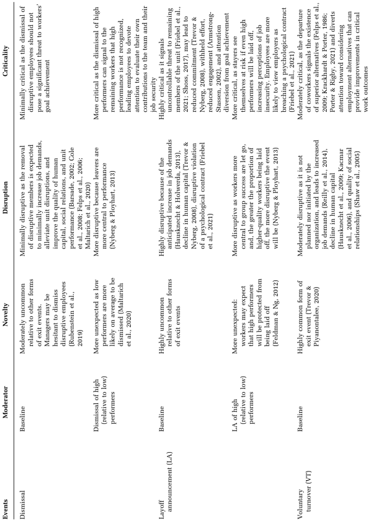

NOTE: complex table shown as an image of the PDF; the text below is a rough machine extraction and may be mis-aligned.

**extracted text (unreliable layout)**

1932 Academy of Management Journal December

Page 5

of disruptive employees should not pose a significant threat to workers’ goal achievement, particularly because disruptive employees themselves might be considered threats to the workers’ achievement of critical goals (Felps et al., 2006), and their removal might contribute to attaining these goals. Therefore, our theory suggests that dismissals are the weakest exit events, and may even decrease voluntary turnover because such events are not usually significantly disruptive or critical and can have positive effects on work unit members’ social and operational functioning. In response to dismissal events, we anticipate the changes in subsequent voluntary turnover rates to be relatively brief compared to other exit events. Few studies show favorable longer-range outcomes following involuntary turnover (Hausknecht & Trevor, 2011). Even when findings show that dismissals lead to operational disruptions, the size of the effect is insignificant (Batt & Colvin, 2011) or small (McElroy et al., 2001). Based on these findings regarding the longer-term consequences of dismissals, we expect the effects of removing disruptions by dismissing dysfunctional members to diminish quickly over time.

Layoff announcements. “Layoffs” are planned workforce reductions that eliminate certain positions to lower costs. At the unit level, announcements of upcoming changes, such as layoffs, serve as warning signs that jobs are at risk (Friebel et al., 2021; Shoss, 2017). We expect that layoff events’ effects on subsequent voluntary turnover rates will be strongest when they are first announced (Cascio, 2002; Trevor & Nyberg, 2008). To provide a more comprehensive understanding of the effects of layoff events, we began our analyses at the time layoffs were announced and continued to examine the effects after the layoffs occurred.

The unit-level changes in job demands, human capital resources, and social relations due to the announcement of layoffs are expected to be strong, because, unlike other types of turnover, those positions affected by layoffs are not expected to be filled (Trevor & Nyberg, 2008). These unfilled positions lead to operational disruption and increased job demands for those who remain (Hausknecht & Holwerda, 2013). They are therefore more impactful than other exit events in which positions are usually promptly filled. By increasing perceptions of job insecurity, layoff announcements pose a threat to a work unit’s viability and the effort level of its members (Friebel et al., 2021). Employees often perceive layoffs and layoff announcements as a disruptive violation of their psychological contracts with their

TABLE 1

(Continued)

Events Moderator Novelty Disruption Criticality

VT of high

(relative to low)

performers

More unexpected because

turnover is less

common among high

performers (Allen &

Griffeth, 1999;

Hausknecht &

Holwerda, 2013)

More disruptive as these unplanned

disruptions are more acute, because

other unit members must abruptly

divide their resources and attention

to coordinate the tasks that had

been disproportionately completed

by high performers (Hausknecht

et al., 2009; Shaw et al., 2005)

More critical, as it leads to greater loss

of human capital, signals viable

employment alternatives for stayers

(Hausknecht et al., 2009; Trevor,

2001), and diverts attention and resources to training and covering

the high performer’s more intensive

workload (Hausknecht et al., 2009)

Notes: The baseline rows show the relative novelty, disruption, and criticality of the particular exit event in comparison to the other exit events. For example, dismissals are

moderately uncommon as compared to layoff announcements, which are highly uncommon, and voluntary turnover events, which are highly common. The rows that denote

the moderator show the comparison of the same exit event for high performers relative to low performers. For example, the dismissal of high performers is more unexpected

relative to the dismissal of low performers.

2023 Sajjadiani, Kammeyer-Mueller, and Benson 1933

Page 6

employers (Friebel et al., 2021; Morrison & Robinson, 1997). Such violations may cause feelings of anger, betrayal, and job insecurity (Brockner, Grover, Reed, & Lee Dewitt, 1992; Laulie & Morgeson, 2021), all of which serve to minimize work groups’ ability to function collectively. This increase in job insecurity in turn can lead to a decrease in the human capital resources and social relationships in the unit through reduced commitment (Trevor & Nyberg, 2008), withheld effort, and reduced engagement (Armstrong-Stassen, 2002; Brockner et al., 1992; Datta, Guthrie, Basuil, & Pandey, 2010; Oreg, Vakola, & Armenakis, 2011). Layoff announcements particularly disrupt the social environment for those with ties to affected employees (Grunberg, Moore, & Greenberg, 2001; Shah, 2000; Wong & McNally, 1994).

Relative to the other exit events, layoffs announcements are strong events. Because layoffs represent large-scale shifts in organizational structure and function, layoffs are rarer than the other exit events, and as such, are highly uncommon (novel). Operational disruptions and disruptions to the psychological contract as discussed above make layoff announcements especially disruptive. The disruption is further increased as layoff survivors actively search for more secure jobs in other organizations. In sum, these are highly disruptive events. The violation of the psychological contract between employer and employee and the increased perceptions of job insecurity that arise as a result make layoff announcements highly critical events, as they signal an uncontrollable threat to the members that remain with the unit (Friebel et al., 2021; Shoss, 2017). From the perspective of TET, because they have such consistent and unambiguous effects on remaining unit members, layoff announcements should therefore strongly affect subsequent voluntary turnover. Consistent with the TET framework, the impacts of layoff announcements on voluntary turnover are expected to diminish over time as the events become less salient (Allen, Freeman, Russell, Reizenstein, & Rentz, 2001).

Voluntary turnover. “Voluntary turnover” events, unlike other exit events, are not initiated by the organization and arise when current employees choose to leave the organization. Therefore, these events lead to a sudden depletion of human capital (Hausknecht, Trevor, & Howard, 2009; Kacmar, Andrews, Van Rooy, Chris Steilberg, & Cerrone, 2006). These unplanned changes result in a lowerthan-desired level of staffing, which necessitates changes to the routines of the work unit. This loss of human capital and reduction in staffing increases

job demands (Reilly et al., 2014) and pressure on other unit members who must divide their resources and attention to cover the tasks of those who have left until new hires come on board (Hausknecht et al., 2009; Shaw, Duffy, Johnson, & Lockhart, 2005). Furthermore, voluntary turnover events disrupt stayers’ social networks and social relationships (Mitchell, Holtom, Lee, Sablynski, & Erez, 2001).

Relative to the other exit events, voluntary turnover is a moderately strong event. Voluntary turnover is seldom as novel as layoff announcements or dismissals to fellow coworkers (Trevor & Piyanontalee, 2020), but it is at least moderately disruptive as the organization and work group leaders are unable to plan for these events in advance and do not select who will leave. They may also have trouble filling the position in a timely fashion. Research on the “contagion” effect of voluntary turnover suggests that the departure of coworkers in a group signals the existence of superior alternatives (Felps et al., 2009; Krackhardt & Porter, 1986; Porter & Rigby, 2021). The event is therefore moderately critical as it captures the attention of the remaining employees, diverting their attention toward considering employment alternatives that can provide improvements in critical work outcomes like wages, working hours, and working conditions. Voluntary turnover events are not as critical as layoff announcements because, whereas voluntary turnover events signal available or preferable employment alternatives, layoff announcements signal the more salient threat of job insecurity.

Taken together, voluntary turnover is a comparatively low-novelty exit event, with moderate levels of disruption, and moderate levels of criticality. Therefore, we expect that subsequent voluntary turnover will be increased following voluntary turnover events to a greater degree than the inconsistent effects of dismissals (which have moderate levels of novelty and weak disruption and criticality), but to a lesser degree relative to the strong impacts of layoff announcements (which have high levels of novelty, disruption, and criticality). We anticipate that the subsequent increase in a work unit’s voluntary turnover rate in the wake of voluntary turnover diminishes over time largely due to decreased disruption. Following the initial shock of departures, a unit adjusts its routines and returns to a predeparture level of functioning. The voluntary turnover of a colleague conveys information concerning employment alternatives, but this effect also decreases and becomes less salient over time.

Overall comparative effects. Summarizing the above arguments, we expect that different types of

1934 Academy of Management Journal December

Page 7

exit events should have different effects on subsequent voluntary turnover rates based on the cumulative pattern of novelty, disruption, and criticality of the events.

Hypothesis 1. (a) Dismissals will have the weakest effect of all turnover events on subsequent turnover; (b) layoff announcements will have the strongest effect of all turnover events on subsequent turnover; (c) voluntary turnover will have a greater effect than dismissals but less than layoff announcements on subsequent voluntary turnover.

Moderating Effects of Human Capital Flow Quality

Next, we turn to the moderating effects of human capital flow quality. We will describe how the quality of human capital flows influence elements of TET. Specifically, our predictions are based on the premise that the levels of novelty, disruption, and criticality of turnover events will differ based on the quality of the human capital of those leaving the organization. Consistent with previous literature (e.g., Campbell, Liao, Chuang, Zhou, & Dong, 2017; Kim & Glomb, 2014), we identify “high-quality workers” as those whose job performance is relatively higher than that of their peers. We index “human capital quality” using average performance ratings for the unit, thereby defining high-quality workers as those whose performance is above the unit’s average.

Human capital flow quality and dismissals. Although there is empirical evidence that low performers are more likely on average to be dismissed (Maltarich et al., 2020), it is possible for high performers to be dismissed as well. Previous studies have demonstrated a low correlation between performance and the type of organizational deviance typically associated with dismissals (Sackett & DeVore, 2001). For instance, individuals with a history of high job performance may still be caught stealing, reducing voluntary helping behavior, showing up late, or missing shifts altogether. All of these activities are grounds for dismissal in most organizations. If the dismissed workers are higher performers, we expect the events to lead to more structural changes related to the job demands and human capital resources of the work unit. The removal of high performers reduces the overall quality of the human capital in the unit (Nyberg, 2010). It is also likely to increase job demands to a greater extent than would low performers’ exit, as high performers are more instrumental to unit performance (Nyberg & Ployhart, 2013).

The quality of the dismissed workers will influence the degree to which dismissal events are novel,

disruptive, and critical. Low performers are typically those who are dismissed; therefore, the removal of high performers is expected to be more surprising and novel to other workers (Maltarich et al., 2020). Due to their track record of making a lower contribution to the work of the unit, the dismissal of low performers is unlikely to create functional disruptions, making this event less disruptive and critical. In this sense, the dismissal of noncontributing low performers is a clear advantage to the remaining workers. In contrast, the dismissal of high performers who have contributed to the work unit successfully is considerably more ambiguous in terms of their leaving being advantageous to the organization, by reducing misconduct or rule violations, but disadvantageous, given that the high performers’ contributions to the workload of the unit are also removed. Additionally, as noted earlier, the basis of the psychological contract is that employees contribute their time and effort to the work group and organization and the organization responds by providing unwritten benefits such as investment in employees and job security (De Meuse, Bergmann, Vanderheiden, & Roraff, 2004; Morrison & Robinson, 1997). Low-performing employees may be seen by their coworkers as not having made this investment, and their dismissal may be perceived as fair. However, the dismissal of high-performing employees for reasons that might not be as salient to the other workers as low performance (e.g., violation of rules and policy) can signal to the remaining workers that high performance does not confer greater job security, leading employees to be concerned about whether their own contributions will lead to job security. The dismissal of high relative to low performers is, therefore, a more critical event.

Hypothesis 2a. Higher leaver performance moderates (decreases) the negative relationship between unitlevel dismissals and subsequent unit-level voluntary turnover.

Human capital flow quality and layoff announcements. Layoffs are based on the financial and operational viability of a work unit as a whole. Therefore, decisions regarding who is to be laid off are not always based on employee performance (Trevor & Piyanontalee, 2020). For example, a retail organization might make the decision to reduce certain departments from the store like a perfume counter, leading to the end of employment for everyone in the department. Such significant losses eliminate work for good and poor performers alike. However, workers may still expect that those who have higher levels of performance will be protected from being

2023 Sajjadiani, Kammeyer-Mueller, and Benson 1935

Page 8

laid off (Feldman & Ng, 2012), and thereby perceive the layoff announcement of high performers as a violation of a psychological contract (Friebel et al., 2021). This elimination of jobs greatly increases job demands for remaining workers, especially in the case that high performers are being laid off. Similarly, if higher performers are being laid off, the human capital resources lost will amount to a greater decline in the human capital of a work unit.

As stated, because high performers are generally less likely to be laid off, layoff announcements that implicate high performers should be perceived as more unexpected or novel than layoff announcements that implicate low performers. Further, the greater the proportion of higher performers who are being laid off, the more disruptive the event will be for operational functioning (Nyberg & Ployhart, 2013). Employees consider an implicit agreement with employers that hard work will be rewarded with job security (Friebel et al., 2021). If high performers, who have invested higher levels of effort and performance in the organization, are not given support to protect their employment by the organization during layoffs, a sense of job insecurity might be exacerbated among layoff survivors. Therefore, the layoff announcement of high performers should be more critical than that of lower performers.

Hypothesis 2b. Higher leaver performance moderates (increases) the positive relationship between unitlevel layoff announcements and subsequent unitlevel voluntary turnover.

Human capital flow quality and voluntary turnover. Finally, the voluntary turnover of high performers will have especially detrimental effects on work-unit functioning relative to the voluntary turnover of lower performers (Hausknecht & Holwerda, 2013). Studies examining turnover regularly find that, notwithstanding the existence of important contextual moderators, voluntary turnover rates among high-performing workers are on average lower than voluntary turnover rates among low performers (e.g., Allen & Griffeth, 1999; Hausknecht & Holwerda, 2013). This is because high performers are better able to positively contribute to the group, are given more positive treatment by coworkers and supervisors, and experience more intrinsic enjoyment due to their success (Judge, Thoresen, Bono, & Patton, 2001). Therefore, the voluntary turnover of high performers is more unexpected than that of low performers.

Previous studies have noted that the voluntary departure of high performers exacerbates the already negative effects of voluntary turnover on job demands, human capital resources, and social relations (Call et al., 2015; O’Boyle & Kroska, 2017). Therefore, these departures are stronger events relative to the voluntary turnover of low performers: these unplanned disruptions are more acute than the disruption due to the departure of low performers because other unit members must abruptly divide their resources and attention to coordinate the tasks that had been disproportionately completed by high performers (Hausknecht et al., 2009; Shaw et al., 2005). These events are also more salient and critical relative to the departure of lower-performing workers, as they demand more attention from remaining workers to maintain previous levels of unit performance, cover the high performer’s more intensive workload, and train their replacements (Call et al., 2015; Hausknecht et al., 2009). High-performer voluntary turnover events can further divert stayer attention by signaling the presence of viable employment alternatives (Hausknecht et al., 2009; Trevor, 2001). In sum, there is greater novelty, disruption, and criticality associated with the departure of high performers relative to the departure of low performers. We therefore anticipate that the departure of high performers will have a stronger impact on subsequent voluntary turnover.

Hypothesis 2c. Higher leaver performance moderates (increases) the positive relationship between unitlevel voluntary turnover and subsequent unit-level voluntary turnover.

METHODS

Setting

Our data come from administrative records of a large U.S. retailer. Retail is a notoriously competitive industry, with low margins, substantial training and labor costs, and staffing requirements that can vary widely throughout the year. Because we collected data from a single organization, we were able to “control” for common characteristics (e.g., industry) that may also affect exit events (Shaw, 2011).

We collected administrative data from 1,620 stores that operated continuously from January 2014 through October 2015, yielding a complete storemonth panel. The stores in our sample were relatively large compared to average U.S. retail

1936 Academy of Management Journal December

Page 9

establishments. During the study period, the stores employed 93.6 workers (SD 5 33.5) on average.<sup>1</sup>

The raw data included the date that each employee was hired and the date and reason corresponding to their turnover, if turnover occurred. From these data, we constructed a person-month panel with a continuation code for the number of months a worker was regularly employed without exiting the unit. Following prior studies (e.g., Maltarich et al., 2020; Reilly et al., 2014; Wang & Zatzick, 2019), we aggregated these data to a store-month panel and operationalized exit events as the count of the exit occurrence divided by the store’s headcount.

Measures

Dismissal rate. For each store-month, we calculated the store-level dismissal rate as the ratio of the number of dismissals in a store due to employee poor performance, poor attendance, lack of integrity, or violations of organizational rules and policies to the number of store employees in that month. To calculate the store-month “population,” we counted all the employees who worked at the store in that month without exiting the unit, regardless of their employment status. Therefore, if they left the store at any point during the month, they were not counted in the store-month population.

Dismissal events are comparatively uncommon in this organization. Dismissals occurred every two months on average, and the average number of workers affected by these events was two workers per event. Dismissals are somewhat correlated with performance. However, there are also cases in which otherwise high-performing employees were dismissed due to poor attendance (29% of the dismissals in this category were high performers), lack of integrity (39% of the dismissals in this category were high performers), or violations of organizational rules and policies (35% of the dismissals in this category were high performers).

Layoff announcement rate. Following previous studies (Trevor & Piyanontalee, 2020), we defined the “layoff rate” as the ratio of the number of

nontemporary workers who were involuntarily terminated due to the elimination of their positions to the number of employees who worked in the store in that month. We excluded temporary and seasonal positions from our sample, because the elimination of such positions is planned at the time of hire (Trevor & Piyanontalee, 2020). Common reasons for layoffs in our sample included staff reductions and subunit closures. In this organization, layoffs were the rarest exit events, occurring every five months, on average, and in each occurrence an average of three workers were affected. Layoffs within this organization are typically announced in the media about two to three months before the events occur. Therefore, we measured the layoff announcement rate based on the layoff rate three months later, assuming that employees were informed about layoffs within their units approximately three months before the events. In our data, 44.30% of laid off employees were high performers.

Voluntary turnover rate. We calculated the store-level voluntary turnover rate for each storemonth as the ratio of the number of voluntary turnover events in a store to the average number of store employees. Common reasons for voluntary turnover included personal reasons, career advancement, returning to school, and job dissatisfaction. Voluntary turnovers occurred every 1.3 months on average, and six workers, on average, quit in each occurrence. In our data, 41.91% of employees who quit are high performers.

Hiring rate. Although we do not theorize about the effects of hiring on subsequent voluntary turnover, due to the interdependence of human capital inflows and outflows, we included hiring rates in our analysis to ensure we take into account this interdependence (Nyberg & Ployhart, 2013; Reilly et al., 2014; Wang & Zatzick, 2019). We calculated the store-month level hiring rate as the ratio of the number of new hires in a store to the number of store employees in that store-month. Similar to previous studies (e.g., Reilly et al., 2014), we only included external hires who joined the unit from outside the organization in our hiring rate, as rehired employees were mainly those whose contracts were renewed. Therefore, they were not new to the work unit and were familiar with the job and the unit’s culture. Likewise, we did not consider transfers and promotions as new hires because the majority of transfers and promotions were within the same unit. In this organization, hiring occurred every 1.5 months on average, and the average number of new hires in each occurrence was 4.6 workers.

1 These stores in our sample employ an average of 93.6 workers in any given month, making them substantially larger than the average U.S. retail store location. The National Retail Federation estimates that there are approximately 4.2 million retail establishments (National Retail Federation, 2020), and there are approximately 32 million retail store workers, suggesting an average of about eight workers per store nationally.

2023 Sajjadiani, Kammeyer-Mueller, and Benson 1937

Page 10

Employee performance. Personnel data included supervisor evaluations of performance. These were the supervisors’ overall evaluation of how employees contributed to the business’s success and workers’ citizenship behavior based on a five-point scale, with higher numbers indicating higher levels of performance. As the performance evaluation occurs annually, we only have performance data for employees who had been with the organization for at least one year. This is a common issue with performance measures. For example, Hale et al. (2016: 921) used the same metric to evaluate the quality of human capital flows, although “many employees or managers lacked performance ratings because they had only recently been hired.” We used this variable to measure the quality of human capital. We created two dummy variables for high and low performance. The high-performance variable is equal to 1 if employee performance is above the unit’s average and 0 if otherwise. The low performance variable is the opposite of the high-performance variable. We then interacted these variables with individual-level turnover dummy variables (dismissals, layoff announcements, and voluntary turnover). Then, we aggregated these variables to the unit-month level to measure the rate of each turnover event for high and low performers.

Controls. Following previous collective turnover studies (Liu, Mitchell, Lee, Holtom, & Hinkin, 2012), we controlled for the effects of demographic variables, including the ratios of White employees, women employees, White managers, women managers, seasonal employees and full-time employees, internal mobility (including within unit promotions and transfers), average hourly pay in the unit-month, and dummy variables indicating the quarter of the year, to rule out the influence of these factors on our findings. We did so by residualizing the dependent variables in the models, by regressing the dependent variables on the control variables, and subtracting the predicted values from the actual values to exclude the effects of these variables on the dependent variables (e.g., Garcıa, Salmeron, Garcıa, & Garcıa, 2020; Sajjadiani, Sojourner, Kammeyer-Mueller, & Mykerezi, 2019). Our results hold with and without the control variables.

Dynamic Analysis

Testing our hypotheses required a general framework for estimating the magnitude and duration of the effects of exit events within and across work units. Static models, and even many longitudinal models with time lags, are not designed to evaluate

the coevolving and interdependent exit events that determine human capital flows (Reilly et al., 2014). Our empirical approach follows Reilly et al.’s (2014) use of PVAR. PVAR is typically used when a model consists of variables that may be mutually endogenous, auto-correlated, and coevolving over time.

PVAR simultaneously estimates the relationship among variables over time using a system of general methods of moments equations (Enders, 2014; Reilly et al., 2014; Wooldridge, 2010). PVAR allowed us to separate these cross-influences and decompose how a change in each exit event variable affected the other events and their future values. For example, PVAR can determine if higher dismissal rates at Time 1 lead to changes in voluntary turnover rates at Time 2. However, it is expected that changes in the voluntary turnover rates at Time 2 may feed back into and influence dismissal rates at Time 3. Because these rates can depend on one another in complex ways, it is difficult to separate how each is contributing to changes in the others using simpler models that do not take into account these complexities and interdependence. PVAR addresses these concerns by estimating the system jointly and decomposing the marginal effect of each exit event on the other events across subsequent periods. Rather than a single static coefficient, PVAR yields an impulse response function, reflecting the marginal effect of a one standard deviation (SD) shock in one exit event on the other exit events over time (Hamilton, 1994; Koop, Pesaran, & Potter, 1996; Pesaran & Shin, 1998; Srithongrung & Kriz, 2014). Impulse responses can vary in magnitude and duration; for instance, one type of exit event may beget a short-term spate of voluntary turnover, while the effects of another type of exit event may be weak but lingering. We are also interested in whether responses to exit events depend on the quality of human capital outflow.

Empirical Implementation

Several implementation decisions are required to meet the identification requirements of a PVAR model. These decisions involve both the ordering of variables and the number of lags in the model. The decision related to ordering is based on theoretical reasons, such that more exogenous variables enter the model earlier, and more endogenous variables enter the model later. As such, the variables entering the model later only affect the future values of the variables that were entered earlier (Love & Zicchino, 2006). This ordering only affects the estimates of the same-period relationships, but future effects, which

1938 Academy of Management Journal December

Page 11

are of interest in our paper, will still be estimated regardless of the order of entry. In other words, each variable can predict future values for all other variables, but, in the same-period analysis, each variable predicts same-period values of only those variables that follow it in the order in which they were entered into the model.

We entered the variables into the model in the following order: (a) layoff announcements, (b) dismissals, (c) hiring, and (d) voluntary turnover. Organizations typically make layoff decisions in advance and based on financial performance. Therefore, it is reasonable to assume that other exit events do not have a contemporaneous effect on layoff announcements. We entered dismissals into the model after layoff announcements, since these decisions also typically depend on an individual’s long-term track record of poor performance. The order of hiring and voluntary turnover in the model is more difficult to determine, as they could theoretically have contemporaneous effects on each other in the same month. We considered voluntary turnover as the most endogenous variable and the last variable that entered into the model. However, to ensure that this ordering did not impact the results, we repeated the analysis once with hiring as the last variable entered. The results were robust to the ordering.

Next, we chose the number of lagged terms in our model using Andrews and Lu’s (2001) three-model selection criteria—minimizing modified Bayesian information criteria, modified Akaike information criterion, and modified quasi information criterion—and the overall coefficient of determination. Applying the selection criteria to models incorporating one to five lags yielded the result that the PVAR model with three lags was optimal. To address potential dimensionality problems that arise when estimating several latent variables, we applied forward mean-differencing using the Helmert transformation (Arellano & Bover, 1995; Love & Zicchino, 2006; Reilly et al., 2014). This procedure removes the forward mean (i.e., the mean of future observations for each store-month) and yields unbiased coefficients while preserving the lagged observations as instruments in the PVAR model. The resulting PVAR model enabled us to forecast the strength and significance of the mutual effects of exit events over subsequent months. We conducted 2,000 Monte Carlo simulations to generate 95% confidence intervals for these effects (Love & Zicchino, 2006).

PVAR models estimate lagged covariances, which can obfuscate the intuitive meaning of effect sizes for audiences interested in cumulative worker-level

effects. Fortunately, approximating the cumulative effect sizes in standard deviation and converting them to the worker level is straightforward because PVAR uses the same scale for the outcome and predictor variables (SDs) and assumes linearity. To do so, first, for each of the 2,000 Monte Carlo simulations, we summed the 12-month impulse response terms to measure the cumulative effects (in SDs) of a 1 SD increase in exit events on subsequent exit events. We used the distribution of the bootstrapped results to provide standard errors for the estimated effects of exit events. To provide a more clear intuition of the cumulative effect sizes, we also report the equivalent worker-level effects in the Results section.

RESULTS

Descriptive Statistics

Exit Events and Voluntary Turnover

The first set of results from our PVAR analysis reveals the dynamic effects of exit events on unitlevel voluntary turnover. We present the impulse response coefficients over time in Table 4, and present a graph based on these results in Figure 1.

Hypothesis 1 proposed how the magnitude and direction of exit events on voluntary turnover rates would vary with respect to each other. To evaluate the three parts of this hypothesis, we first report the direct effects of each exit event on voluntary turnover, then compare the magnitude and duration of their cumulative effects.

Consistent with our initial hypothesis, we find that the effect of dismissals on future quits is comparatively small. A 1 SD increase (1.1 workers) in the dismissal rate was associated with a significant decrease in the voluntary turnover rate in the following month (bM1 5 20.07, p , .001), but the effect disappeared thereafter. We anticipated that, following layoff announcements, unit-level turnover rates would increase to a large extent. As expected, during the first two months after a 1 SD increase in layoff announcements (0.42 positions), voluntary turnover rates increased significantly (bM1 5 0.24, p , .001; bM2 5 0.09, p , .05). The effects were not significant in the subsequent months. Finally, a 1 SD (2.78 workers) increase in voluntary turnover had no significant effect on the voluntary turnover rate in the

2023 Sajjadiani, Kammeyer-Mueller, and Benson 1939

Page 12

first month. However, the voluntary turnover rate accelerated in the following three months after the shock (bM2 5 0.06, p , .01; bM3 5 0.12, p , .001; bM4 5 0.03, p , .001). This result, showing an increase in voluntary turnover, is again consistent with our expectations.

Next, to compare the effects of the exit events, based on the results of the 2,000 Monte Carlo

simulations, we calculated the cumulative effect of each event on voluntary turnover and then conducted a t test to compare the mean value of each cumulative effect over 2,000 iterations with zero. Next, we calculated the p value for the differences between the cumulative effects of each pair of events, which was zero for all pairs, indicating that the cumulative effects of each exit event on

TABLE 2 Descriptive Statistics

[output not shown]

NOTE: table converted from PDF layout to HTML text; cell boundaries are reconstructed. See PDF if exact alignment matters.

Notes: n 5 35,640 observations from 1,620 stores (units) over 22 months. Rates are reported at the monthly level. Mean and standard deviation (SD) are calculated within the store and then averaged. Grand minimum (min.) and maximum (max.) are reported for each variable.

TABLE 3 Within-Store and Between-Store Intercorrelations Between Variables

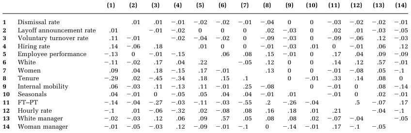

NOTE: complex table shown as an image of the PDF; the text below is a rough machine extraction and may be mis-aligned.

**extracted text (unreliable layout)**

Notes: Correlation values greater than .05 are significant at p , .05. Correlations below the diagonal are between unit correlations (n 5 1,620 stores). Correlations above the diagonal are the within-unit correlations over 22 months.

1940 Academy of Management Journal December

Page 13

subsequent voluntary turnover were significantly different from the cumulative effects of the other exit events. Results are reported in Table 4. These results support Hypotheses 1a, 1b, and 1c.

To provide an intuition for the estimated magnitude of these differences, consider that the stores, on average, employed 93.6 workers per month. According to Table 2, 1 SD of the voluntary turnover rate is equivalent to 2.97% of a typical store’s population (or 2.78 workers). For example, a 1 SD increase in the dismissal rate (1.1 workers) is associated with a decrease of 0.07 SD (0.19 workers) in the subsequent voluntary turnover in the following month (bM1 5 20.07, p , .001 or 0.073 2.97% 3 93.6 workers or 0.19 workers). Following this pattern and based on the last column in Table 4, which shows the cumulative effects of exit events, a 1 SD increase in layoff announcements (0.42 positions eliminated) is associated with an increase of 0.34 SD (0.95 workers) in the subsequent voluntary turnover rate over two months. Finally, a 1 SD increase in voluntary turnover (2.78 workers) is associated with an increase of 0.23 SD (0.64 workers) in the subsequent voluntary turnover rate over the following six months. To better illustrate the differences in the cumulative effects, we also calculated how many workers would quit in the subsequent months if one worker faced each of these exit events: the cumulative effect of one worker’s turnover event, including dismissal, layoff announcement, and voluntary turnover, on subsequent voluntary turnover is a decrease of 0.17 workers, an increase of 2.2 workers, and an increase of 0.23 workers, respectively.

The Moderating Effect of Human Capital Quality

Our second hypothesis proposed that human capital quality would moderate the relationship between exit events and subsequent voluntary turnover rates. As presented in Figure 2 and Table 5, Panel A, a 1 SD increase in the dismissal rate of high performers was not associated with any significant changes in subsequent unit-level voluntary turnover. However, a 1 SD increase in dismissing low performers was associated with a slight decrease (0.04 SD or 0.11 workers) in subsequent voluntary turnover for one month. These results provide marginal support for Hypothesis 2a. As presented in Figure 2 and Table 5, Panel A, our results did not provide sufficient support for Hypotheses 2b and 2c to conclude that the human capital quality of departing employees operated as a moderator. Though our initial estimates concern the effect of high and low-performer turnover on subsequent turnover on average, small or null effects on average may mask heterogeneity in subsequent turnover across groups. We explore this possibility in the next section.<sup>2</sup>

TABLE 4 Impulse Response of Voluntary Turnover to Shocks in Exit Events over Months

[output not shown]

NOTE: table converted from PDF layout to HTML text; cell boundaries are reconstructed. See PDF if exact alignment matters.

Notes: Robust standard errors (in parentheses). Months indicate months after a one-time, one-standard deviation (SD) shock in the exit variables. Nall 5 29,358 unit-months. The last column illustrates the cumulative effects of a 1 SD increase in the event’s rate on subsequent unit-level voluntary turnover rates after 12 months. Using 2,000 Monte Carlo simulations, we calculated the cumulative effect of each event on subsequent voluntary turnover and conducted a t test to compare the mean value of the cumulative effects over 2,000 iterations with 0. We also calculated the p value for the differences between the cumulative effects of each pair of events, which was zero for all pairs, indicating that the cumulative effects of each exit event on subsequent voluntary turnover were significantly different from the cumulative effects of the other exit events.

p , .05 p , .01 p , .001

2 We repeated the analysis using a different definition for high and low performers. Instead of defining high performance as 1 if the employee’s performance is above the unit’s average and 0 otherwise, this time, we defined high performers as the top 40% of workers in terms of performance and low performers as the bottom 40% of workers. This analysis yielded similar results in terms of magnitude, direction, and significance of effects.

2023 Sajjadiani, Kammeyer-Mueller, and Benson 1941

Page 14

Supplemental Analyses

Below, we evaluate the properties of dismissals, contrast layoffs and layoff announcements and the relationship between exit events and subsequent voluntary turnover for high versus low performers.

Dismissals. We theorized that dismissals would be associated with a decrease in subsequent voluntary turnover, assuming that dismissals are

perceived as fair. Unfortunately, we did not have a measure of perceived dismissal fairness. However, we were able to conduct a PVAR analysis that evaluated this question by dividing dismissal events into two separate constructs based on the reason for dismissal: dismissal for poor performance (task performance or behavioral performance) versus dismissal for misconduct (including poor attendance, lack of

FIGURE 1 Impulse Response of Voluntary Turnover to Shocks in Exit Events over Months

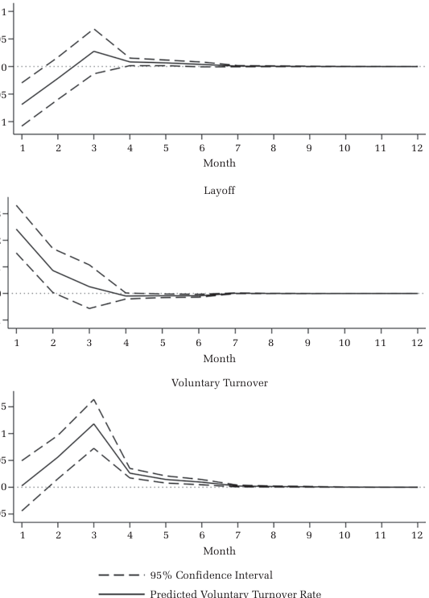

NOTE: figure/graphic rendered as an image from the PDF; its content is not machine-readable text. Caption (if any) follows as the next block.

**text found inside the figure**

1942 Academy of Management Journal December

Page 15

TABLE 5

Impulse Response of Voluntary Turnover to Shocks in Exit Events over Months

Panel A Panel B Panel C

VT VT of high performers VT of low performers

Shock variable M1 M 2 M3 M4 M1 M2 M3 M4 M 1 M 2 M 3 M 4

Dismissal of high performers 0.02 20.01 0.01 0.00 0.03 0.02 0.03 0.01 20.01 20.00 20.01 20.00 (0.01) (0.01) (0.01) (0.00) (0.01) (0.01) (0.01) (0.00) (0.01) (0.01) (0.01) (0.00)

Dismissal of low performers 20.04 0.00 0.01 20.00 20.01 20.01 20.00 20.00 0.02 0.03 0.02 0.01

(0.02) (0.01) (0.02) (0.00) (0.01) (0.00) (0.00) (0.00) (0.01) (0.01) (0.01) (0.00)

Difference 0.06 20.01 0.00 0.00 0.04 0.03 0.03 0.01 20.03 20.03 20.03 20.01

(0.02) (0.02) (0.02) (0.00) (0.01) (0.01) (0.01) (0.00) (0.01) (0.01) (0.01) (0.00)

Layoff of high performers 0.13 0.05 0.05 20.01 0.06 0.02 0.01 0.00 0.04 0.01 20.00 0.00 (0.03) (0.02) (0.02) (0.00) (0.01) (0.01) (0.01) (0.00) (0.01) (0.01) (0.01) (0.00)

Layoff of low performers 0.11 0.02 20.01 20.01 0.02 20.00 20.01 20.00 0.03 0.02 20.02 0.00 (0.02) (0.02) (0.02) (0.00) (0.01) (0.01) (0.01) (0.00) (0.01) (0.01) (0.01) (0.00)

Difference 0.02 0.03 0.06 20.00 0.04 0.02 0.02 0.00 0.01 20.01 0.02 0.00 (0.04) (0.03) (0.03) (0.01) (0.01) (0.01) (0.01) (0.00) (0.02) (0.01) (0.02) (0.00)

VT of high performers 20.02 20.03 0.04 0.00 0.06 0.05 0.06 0.01 20.03 20.03 20.01 20.01

(0.02) (0.02) (0.02) (0.00) (0.01) (0.01) (0.01) (0.00) (0.01) (0.01) (0.01) (0.00)

VT of low performers 20.00 0.05 0.02 0.01 20.01 20.00 20.02 20.00 0.07 0.07 0.05 0.01

(0.02) (0.02) (0.02) (0.00) (0.01) (0.01) (0.01) (0.00) (0.01) (0.01) (0.01) (0.00)

Difference 20.02 20.08 0.02 20.01 0.07 0.05 0.08 0.01 20.10 20.10 20.06 20.02

(0.02) (0.02) (0.02) (0.00) (0.01) (0.01) (0.01) (0.00) (0.01) (0.01) (0.01) (0.00)

Notes: Due to a lack of space, this table only shows the responses over four months. Complete results are presented in Figure 2. Months indicate months after one-time, one

standard deviation shock in the exit variables. VT 5 voluntary turnover. Robust standard errors (in parentheses).

We repeated the analysis using a different definition for high and low performers. Instead of defining high-performance as 1 if the employee’s performance is above the

unit’s average and 0 otherwise, we defined high performers as the top 40% of workers in terms of performance and low performers as the bottom 40% of workers. This analysis

yielded similar results in terms of magnitude, direction, and significance of effects.

p , .05

p , .01

p , .001

2023 Sajjadiani, Kammeyer-Mueller, and Benson 1943

Page 16

integrity, or violations of organizational rules and policies). Therefore, the construct of dismissal for poor performance includes the dismissal of workers who were disruptive behaviorally or operationally, but not those who engaged in poor attendance, lack of integrity, or violation of organizational rules and policies because those comprise the measure for dismissal for misconduct.

If dismissals for poor performance were perceived as more fair, or if these reasons were more salient and understandable to workers than dismissals for misconduct, we should observe a stronger turnoverreducing pattern in response to dismissals for poor performance versus dismissals for misconduct. This effect is expected to occur because the operational or behavioral disruption caused by poor performers should be more salient to the employees and they should be less likely to perceive these dismissal as

unfair, whereas, in cases in which workers are dismissed for reasons such as the violation of rules and policy or lack of integrity, other employees might have a more heterogeneous opinion about the fairness of the decision or otherwise may not be fully informed of the reason for the dismissal.

As shown in Figure 3, only the dismissal of poor performers led to decreased voluntary turnover rates in the subsequent month, while dismissal for misconduct did not have any significant effect on voluntary turnover rates.

Layoffs versus layoff announcements. Our review of media reports related to layoff announcements in this organization showed that layoffs were typically announced about three months before jobs were eliminated. Therefore, we assumed layoff announcements occurred three months prior to layoff events. To assess whether the effects on voluntary

FIGURE 2 Impulse Response of Voluntary Turnover to Shocks in Exit Events of High versus Low Performers

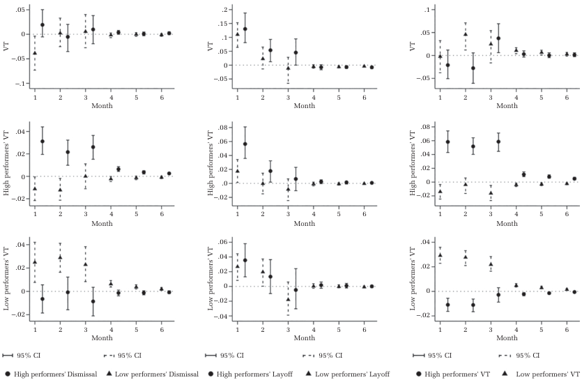

NOTE: figure/graphic rendered as an image from the PDF; its content is not machine-readable text. Caption (if any) follows as the next block.

.05

–.05

–.1

1 2 3

Month

Month

4 5

VT

6

1 2 3 4 5 6

0

.04

0

High performers' VT

High performers' Dismissal

.02

–.02

Month 1 2 3 4 5 6

.04

0

Low performers' VT

Low performers' Dismissal

.02

–.02

.2

.05

.1

.15

–.05

1 2 3

Month

Month

4 5

VT

6

1 2 3 4 5 6

0

.08

.02

.0

High performers' VT

.04

.06

–.02

Month 1 2 3 4 5 6

.06

–.02

0

Low performers' VT

.02

.04

–.04

.1

0

–.05

1 2 3

Month

Month

4 5

VT

6

1 2 3 4 5 6

.05

.08

0

High performers' VT

.06

.04

.02

–.02

Month 1 2 3 4 5 6

.04

0

Low performers' VT

.02

–.02

95% CI

High performers' Layoff

95% CI

High performers' VT

95% CI 95% CI

Low performers' Layoff

95% CI

Low performers' VT

95% CI

Dismissal

Layoff

VT

Note: VT 5 voluntary turnover.

1944 Academy of Management Journal December

Page 17

[figure not shown]

NOTE: figure/graphic rendered as an image from the PDF; its content is not machine-readable text. Caption (if any) follows as the next block.

[figure not shown]

NOTE: figure/graphic rendered as an image from the PDF; its content is not machine-readable text. Caption (if any) follows as the next block.

[figure not shown]

NOTE: figure/graphic rendered as an image from the PDF; its content is not machine-readable text. Caption (if any) follows as the next block.

[figure not shown]

NOTE: figure/graphic rendered as an image from the PDF; its content is not machine-readable text. Caption (if any) follows as the next block.

[figure not shown]

NOTE: figure/graphic rendered as an image from the PDF; its content is not machine-readable text. Caption (if any) follows as the next block.

[figure not shown]

NOTE: figure/graphic rendered as an image from the PDF; its content is not machine-readable text. Caption (if any) follows as the next block.

[figure not shown]

NOTE: figure/graphic rendered as an image from the PDF; its content is not machine-readable text. Caption (if any) follows as the next block.

[figure not shown]

NOTE: figure/graphic rendered as an image from the PDF; its content is not machine-readable text. Caption (if any) follows as the next block.

[figure not shown]

NOTE: figure/graphic rendered as an image from the PDF; its content is not machine-readable text. Caption (if any) follows as the next block.

turnover are strongest when the event is announced, we repeated our analyses by treating layoff announcements as if they occurred three, two, or one month(s) prior to job elimination, or at the time when the layoff took effect. As presented in Figure 4, we observed a downward (but not statistically significant) trend in the subsequent voluntary turnover rate in response to layoffs (the moment job elimination occurred), and an increase in subsequent voluntary turnover in response to layoff announcements for both the two-month and the three-month models.

Flows by the quality of human capital. Our main analysis considered whether high- or low-quality human capital exits had differential effects on voluntary turnover rates. However, when comparing the departures of high performers and low performers, small differences in subsequent voluntary turnover may mask large differences across groups of high versus low performers. Figure 2 and Table 5, Panels B and C, and Table 6 provide estimates for the effects of high- or low-performer exits on subsequent

high- or low-performer voluntary turnover rates (rather than voluntary turnover averaged across highand low-performing groups), and how these effects vary across dismissals, layoffs, and quits.

These tables illustrate stark differences in turnover across different groups, and, in particular, the finding that high-performer exits are accompanied by subsequent high-performer voluntary turnover, and low-performer exits are accompanied by subsequent low-performer voluntary turnover. Dismissing one high performer leads to 0.3 further quits among the work unit’s high performers, and a 0.08 decline in quits among low performers. Dismissing a low performer has a symmetric effect, greatly increasing quits among low performers and slightly reducing quits among high performers. Additionally, eliminating one high performer’s position strongly impacts subsequent quits among both high and low performers (0.41 and 0.28 workers quit, respectively), while eliminating one low performer’s position only increases voluntary turnover among high

FIGURE 3 Dismissals for Poor Performance versus Misconduct

1 2 3 4 5 6 7 8 9 10 11 12

[figure not shown]

NOTE: figure/graphic rendered as an image from the PDF; its content is not machine-readable text. Caption (if any) follows as the next block.

1

.04

–.1

–.05

0

.05

.1

.02

0

–.02

–.04

–.06

2 3 4 5 6 7

[figure not shown]

NOTE: figure/graphic rendered as an image from the PDF; its content is not machine-readable text. Caption (if any) follows as the next block.

Month

8 9 10 11 12

[figure not shown]

NOTE: figure/graphic rendered as an image from the PDF; its content is not machine-readable text. Caption (if any) follows as the next block.

Month

Dismissals due to Misconduct

Dismissals of Poor Performers

Voluntary Turnover Voluntary Turnover

95% Confidence Interval

Predicted Voluntary Turnover Rate

2023 Sajjadiani, Kammeyer-Mueller, and Benson 1945

Page 18

and low performers by 0.04 and 0.14 workers, respectively. Finally, when one high performer voluntarily leaves, it leads to a cumulative increase of 0.19 high performers quitting and a decrease of 0.09 low performers quitting. In contrast, when one low performer quits, it only decreases voluntary turnover among high performers in subsequent months by 0.03 workers, but leads to 0.22 additional low performers quitting. These results suggest that consequences of exit events are likely to be magnified beyond the workers directly affected by the exits, particularly among workers of a similar type, in the work unit. Put another way, turnover contagion is likely to be acute among workers of a similar type, but largely contained to workers of that type.

To explain these differentially patterned results, we use comparative levels of disruption and criticality, as well as theories concerning signaling, social comparison, and social networks. We further discuss

the theoretical and practical implications of these findings in the Discussion section.

DISCUSSION

Human capital flows out of a work unit in the form of exit events are inevitable and can produce significant impacts on work-unit functioning (Trevor & Piyanontalee, 2020). As such, a system for understanding and predicting the variable downstream effects of these events is imperative (Li & van Knippenberg, 2021). Our unifying theoretical framework drew from TET and prior work on the effects of exit events on structural changes with regard to job demands, human capital resources, and social relations within work units. The resulting systematic outlook shed light on the differential effects of exit events on subsequent unit-level voluntary turnover, with the strongest effects stemming from layoff

FIGURE 4 Layoff Events Relative to Layoff Announcements

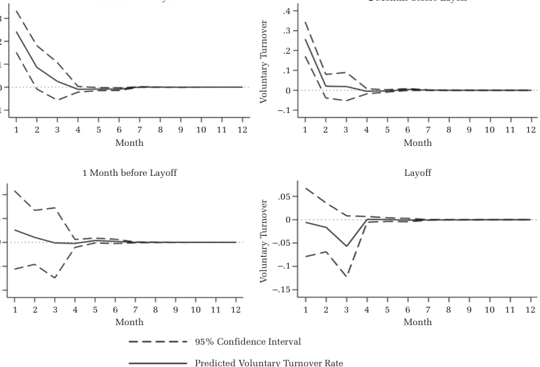

NOTE: figure/graphic rendered as an image from the PDF; its content is not machine-readable text. Caption (if any) follows as the next block.

1 2 3 4 5 6 7 8 9 10 11 12

1 2 3 4 5 6 7 8 9 10 11 12 12 11 10 9 8 7 1 2 3 4 5 6

Month

Month

1 Month before Layoff Layoff

1 2 3 4 5 6 7 8 9 10 11 12 Month

Month

.3

.4

.2

.1

0

–.1

.05

0

–.05

–.1

–.15

95% Confidence Interval

Voluntary Turnover

Voluntary Turnover

3 Months before Layoff

.3

.2

.1

0

–.1

2 Months before Layoff

.1

.05

0

–.05

–.1

Predicted Voluntary Turnover Rate

Voluntary Turnover

Voluntary Turnover

1946 Academy of Management Journal December

Page 19

announcement events, more moderate effects from voluntary turnover events, and the least pronounced effects resulting from dismissal events. We also differentiated the short- and long-term implications by treating exit events as endogenous, coevolving parts of a dynamic system with interacting effects that unfold over time. The TET understanding of human capital flow quality further suggested there would be moderating effects of the performance levels of those leaving the work unit on subsequent voluntary turnover of high versus low performers.

Theoretical Implications

We contribute to the strategic human resources and turnover literatures in several respects. First, we provide a generalizable description of the factors that make exit events distinct in their impacts on subsequent voluntary turnover. We used the constructs of novelty, disruption, and criticality from TET to differentiate and compare the consequences of different exit events. This enabled us to generate specific and testable hypotheses related to the consequences of different forms of exit events. One important implication of this dynamic and systemic approach concerns studies that treat a single exit event as an outcome that is conditionally uncorrelated with other potential exit events. In general, such analyses may underestimate effects on work-unit exit because effects probabilistically “multiply” across workers of similar types.

Second, we made novel distinctions within the original TET constructs of voluntary and involuntary

turnover events by separating the construct of involuntary turnover into dismissals and layoffs. We further specified between the consequences of layoff announcements versus layoffs. Distinguishing turnover event constructs into more specific exit events allowed us to elaborate their unique effects and shed light on some theoretical models that have not yet been empirically examined. For instance, previous studies conceptually argued that voluntary turnover should increase more in response to voluntary turnover than involuntary turnover without differentiating between dismissals and layoffs (Porter & Rigby, 2021; Trevor, 2001). Other studies (e.g., Batt, Colvin, & Keefe, 2002; Trevor & Nyberg, 2008) demonstrated that layoffs are predictive of subsequent voluntary turnover, but did not include a contrast between dismissals and layoff announcements. Our results show that layoff announcements have a strong positive effect on the subsequent voluntary turnover rate. However, dismissals slightly decrease the subsequent voluntary turnover rate for a short period of time. Concerning the effects of layoff announcements on voluntary turnover, our results demonstrate the importance of distinguishing between layoffs and layoff announcements (Friebel et al., 2021). Our supplemental analyses confirmed that the effects of layoff events on subsequent voluntary turnover rates predominantly occurred promptly after the layoffs were announced. We did not observe effects on subsequent voluntary turnover rates following layoffs. This may be because many of those who intended to leave already did so after the layoffs were announced. We also found that turnover

TABLE 6 Cumulative Effects of Exit Events on Voluntary Turnover of High versus Low Performers

[output not shown]

NOTE: table converted from PDF layout to HTML text; cell boundaries are reconstructed. See PDF if exact alignment matters.

Notes: We used the results of the Monte Carlo simulation with 2,000 iterations to determine the cumulative effect of each exit event on subsequent voluntary turnover. To make these effects comparable, we converted the effects (in standard deviations (SDs)) of each exit event on subsequent voluntary turnover (VT) of high and low performers to the worker level and calculated how many workers would quit if only one worker was affected by the event. This was done by multiplying the cumulative effect obtained from the simulation by the ratio of the subsequent VT’s SD to the SD of the event. The first two columns show the cumulative effects of a 1 SD shock in the exit events on the VT of high and low performers. The last two columns show how many high (low) workers would quit in response to one worker being affected by the exit event. “H(L)VT” stands for high (low) voluntary turnover. Standard error is equal to zero for all the effects.

p , .05 p , .01 p , .001

2023 Sajjadiani, Kammeyer-Mueller, and Benson 1947

Page 20

rates increased sooner after layoff announcements than after voluntary turnover events. An explanation for this finding might be that these events transmit different signals to remaining employees. Layoff announcements provide signals regarding the outcomes within the organization that lie outside of the workers’ control, including increased job insecurity, the urgency to find a new job, and a breach of a psychological contract. Voluntary turnover events, conversely, provide signals related to options outside of the organization that do lie within the workers’ ability to respond to them. Therefore, those who leave after voluntary turnover may feel they have more time and agency in reacting to the event and will therefore be more discerning when searching for a new position, as compared to those who leave after layoff announcements, who may be less selective out of a sense of urgency.

Third, none of our predictions about leaver performance as a moderator of the departure-subsequent voluntary turnover relationship received significant support. Our expectations about event novelty, disruption, and criticality associated with the departure of high performers being more substantial overall than the departure of low performers did not correspond to the pattern of relationships in these data. These results suggest that, at the very least, there are some important nuances to prior theory regarding the quality of human capital outflows and disruption in work units (Hausknecht & Holwerda, 2013). Our hypotheses were based on the premise that the reactions of the work unit as a whole were dependent on the relative disruption caused by the departure of high versus low performers. It may be that departures have different effects on different types of unit members. We investigated this possibility in our supplementary analyses by distinguishing between the effects of exit events of high and low performers on the subsequent voluntary turnover of high performers versus low performers and did find a pattern of differential effects.

Although we did not hypothesize these differential effects, TET could provide a tentative explanation. The results revealed that high performers reacted to events involving other high performers, and low performers reacted to events involving other low performers. The concepts of comparative levels of disruption and criticality are especially relevant in explaining these results. It is possible that high performers experience greater levels of disruption when other high performers leave. It may be that the departure of high performers is particularly disruptive to the well-established patterns of successful

workers (i.e., comparatively higher disruption) who have a higher level of investment in the work (i.e., comparatively higher criticality). It is also possible that the impact of departing high performers will be less disruptive for low performers because their routines are neither strongly established (i.e., comparatively lower disruption) nor are the workers as invested in the organization (i.e., comparatively lower criticality). Further research should endeavor to address the mechanism through which this specific form of contagion occurs. This higher level of disruption and criticality for different types of workers may be explained by social network theories. Prior evidence suggests that high performers tend to be more connected to other high performers through their advice and friendship networks, and may experience more powerful events when these connections are severed (H^ancean, Perc, & Lerner, 2021). On the other hand, low performers may be more connected to other low performers within the organization, and may be more likely to leave when these connections are severed. Conversely, this effect might also be explained through the lens of social comparison theory (e.g., Porter & Rigby, 2021; Trevor, 2001), where high-performing employees might observe those considered to be similar to themselves making decisions to leave and decide that is the proper course of action for themselves as well. Low performers may not make a comparison between their status and the status of high performers and thus not use these observations to inform their decision-making.

Furthermore, our results imply that the voluntary turnover of high performers may not only motivate other high performers to leave, it also may decrease the voluntary turnover of low performers, making voluntary turnover of high performers particularly costly. This can be because voluntary turnover of high performers might be a particularly critical event for other high performers as it sends signals to other high performers that there are external opportunities, increasing high-performer perceptions of ease of movement (Trevor, 2001). This signal might not be as relevant to the low performers.

The differentially patterned results for involuntary turnover events could also be explained by signaling theory or social comparison theory (Porter & Rigby, 2021; Trevor, 2001). Both of these theories suggest that we evaluate the implications of events in terms of “if it happened to someone like me, it could happen to me too.” This differential result can be linked to event criticality—in other words, events can be particularly critical for certain groups of

1948 Academy of Management Journal December

Page 21

employees, depending on the signal they receive from the event. As we noted, the involuntary departure of high performers due to either layoffs or dismissals might be perceived as a violation of the psychological contract in which those who have contributed the most to the organization are not given parallel consideration by the organization (Friebel et al., 2021; Morrison & Robinson, 1997). Other high performers might believe that high performance is not rewarded within their organization, making these departures relevant as threats to critical outcomes. Regarding our findings showing that low performers quit more in response to the termination of other poor performers, previous studies have also alluded to the notion that the perceived possibility of discharge may drive some poor performers to quit before they are terminated (Jackofsky, 1984; Trevor & Piyanontalee, 2020). Our findings provide some empirical evidence for this proposition concerning the valued voluntary exits of lowperforming employees.

Practical Implications

This paper developed a relative order for the strength of each exit event’s effects on subsequent voluntary turnover, identifying layoff announcements as the strongest voluntary turnover-increasing exit event—especially when high performers are those being laid off. Exit events spill over to future voluntary turnover, so organizations facing high volatility in unit membership may not be able to maintain effective interdependent teams. In light of these findings, the long-standing advice that organizations should make efforts to minimize voluntary turnover takes on an elevated level of importance. Organizations with long training periods or that face the adverse consequences of understaffing or overstaffing might make particularly strong efforts to minimize the occurrence of exit events to increase operational stability and return on investment from developing human capital. Managers and administrators should carefully consider the consequences of announcing layoffs, as, according to our model, layoff announcements are the most salient voluntary turnover-increasing exit event.

Furthermore, organizations should recognize that the departure of high performers has compounding negative effects on unit-level human capital. We found that the voluntary turnover of high performers was associated with a spiraling effect on human capital flows as it increased the voluntary turnover of other high performers and decreased the voluntary

turnover of low performers. This means that the problem of departing high-quality employees is even more dire than our original hypotheses predicted, as a vicious cycle of declining human capital quality occurs. The voluntary turnover of high performers decreases human capital directly, just as the further loss of other high performers in subsequent unitlevel voluntary turnover continues to deplete human capital. However, that low performers are more likely to remain with the unit following the voluntary turnover of high performers further compounds these deleterious effects on unit-level human capital. Regarding the tendency for low performers to follow other low performers after their dismissal, organizations can view these exit events as valued exits (Trevor & Piyanontalee, 2020). Motivating other low performers to quit and seek out other employment opportunities before being formally dismissed can potentially prevent consequent legal or social ramifications (Trevor & Piyanontalee, 2020).

Limitations and Directions for Future Research

Our study has several limitations that highlight opportunities for future research. First, our results can be generalizable to the retail sector or other occupations in which replacement of human capital requires minimal preparation and training. Such jobs broadly correspond to low task-complexity occupations. Workers are also less invested in these jobs because they are simply less invested in their work. If our conceptual model is correct, this means that a unit’s response to losses in human capital might be greater in occupations with higher stability in staffing, greater complexity of routines, and higher human capital investment. These job-related factors correspond to novelty, disruption, and criticality, respectively. Future research might build on our framework by evaluating different occupations and work contexts that are likely to have different levels of event strength. As an example, it might be expected that the downstream impacts of voluntary turnover would be greater in work settings where voluntary turnover happens less often because such events would be more novel and disruptive relative to a very large firm in the retail industry (Oslund, 2019). Second, although we considered some heterogeneity in exit events, such as the quality of departing workers, our data prevented us from accounting for other likely sources of variation in the exit events, such as job level or employment type. Future studies could investigate whether exit events have different

2023 Sajjadiani, Kammeyer-Mueller, and Benson 1949

Page 22

effects on workers in various job levels (e.g., management- vs. floor-level workers) or employment types (i.e., full- vs. part-time workers).

Third, while we could operationalize human capital flow quality using supervisor-designated performance scores, we could not ascertain a more objective measure of human capital quality. Furthermore, as performance scores were completed annually, we only had data for those who had been with the organization for at least one year. By accessing objective metrics for employee performance throughout their period of employment, researchers can circumvent this limitation. Future studies should also seek more objective and direct measures of event novelty, disruption, and criticality.

Finally, we found that high and low performers respond differently to exit events and discussed some possible mechanisms that can lead to these results. Future studies could potentially shed light on these results by exploring the mechanisms that led employees to react more strongly to events that involved employees with similar levels of performance.

CONCLUSION

In sum, our study represents a novel extension of previous work related to exit events and quality of human capital outflows. We demonstrate that turnover events, even when they may be perceived as valued exits, lead to different subsequent unit-level voluntary turnover depending on the nature of the event—the degree to which an event is novel, disruptive, or critical, and whether the event involves high or low performers.

REFERENCES

Allen, D. G., & Griffeth, R. W. 1999. Job performance and

turnover: A review and integrative multi-route model. Human Resource Management Review, 9: 525–548.

Allen, T. D., Freeman, D. M., Russell, J. E. A., Reizenstein,

R. C., & Rentz, J. O. 2001. Survivor reactions to organizational downsizing: Does time ease the pain? Journal of Occupational and Organizational Psychology, 74: 145–164.

Andrews, D. W. K., & Lu, B. 2001. Consistent model and

moment selection procedures for GMM estimation with application to dynamic panel data models. Journal of Econometrics, 101: 123–164.

Arellano, M., & Bover, O. 1995. Another look at the instru-

mental variable estimation of error-components models. Journal of Econometrics, 68: 29–51.

Armstrong-Stassen, M. 2002. Designated redundant but escaping lay-off: A special group of lay-off

survivors. Journal of Occupational and Organizational Psychology, 75: 1–13.

Barsade, S. G. 2002. The ripple effect: Emotional contagion

and its influence on group behavior. Administrative Science Quarterly, 47: 644–675.

Batt, R., Colvin, A. J. S., & Keefe, J. 2002. Employee voice,

human resource practices, and quit rates: Evidence from the telecommunications industry. Industrial & Labor Relations Review, 55: 573–594.

Batt, R., & Colvin, A. J. S. 2011. An employment systems

approach to turnover: Human resources practices, quits, dismissals, and performance. Academy of Management Journal, 54: 695–717.

Brockner, J., Grover, S., Reed, T. F., & Lee Dewitt, R. 1992.

Layoffs, job insecurity, and survivors’ work effort: Evidence of an inverted-U relationship. Academy of Management Journal, 35: 413–425.

Burke, C. S., Stagl, K. C., Klein, C., Goodwin, G. F., Salas,

E., & Halpin, S. M. 2006. What type of leadership behaviors are functional in teams? A meta-analysis. Leadership Quarterly, 17: 288–307.

Call, M. L., Nyberg, A. J., Ployhart, R. E., & Weekley, J.

2015. The dynamic nature of collective turnover and unit performance: The impact of time, quality, and replacements. Academy of Management Journal, 58: 1208–1232.

Campbell, E. M., Liao, H., Chuang, A., Zhou, J., & Dong, Y.

2017. Hot shots and cool reception? An expanded view of social consequences for high performers. Journal of Applied Psychology, 102: 845–866.

Cascio, W. F. 2002. Responsible restructuring: Creative

and profitable alternatives to layoffs. Oakland, CA: Berrett-Koehler.

Cole, M. S., Walter, F., & Bruch, H. 2008. Affective mecha-

nisms linking dysfunctional behavior to performance in work teams: A moderated mediation study. Journal of Applied Psychology, 93: 945–958.

Datta, D. K., Guthrie, J. P., Basuil, D., & Pandey, A. 2010.

Causes and effects of employee downsizing: A review and synthesis. Journal of Management, 36: 281–348.

De Meuse, K., Bergmann, T., Vanderheiden, P., & Roraff, C.

2004. New evidence regarding organizational downsizing and a firm’s financial performance: A long-term analysis. Journal of Managerial Issues, 16: 155–177.

Enders, W. 2014. Applied econometric times series. New

York, NY: Wiley.

Feldman, D. C., & Ng, T. W. H. 2012. Selection out: How

firms choose workers to lay off. In N. Schmitt (Ed.), The Oxford handbook of personnel assessment and selection: 849–864. New York, NY: Oxford University Press.

Felps, W., Mitchell, T. R., & Byington, E. 2006. How,

when, and why bad apples spoil the barrel: Negative

1950 Academy of Management Journal December

Page 23

group members and dysfunctional groups. Research in Organizational Behavior, 27: 175–222.

Felps, W., Mitchell, T. R., Hekman, D. R., Lee, T. W., Hol-

tom, B. C., & Harman, W. S. 2009. Turnover contagion: How coworkers’ job embeddedness and job search behaviors influence quitting. Academy of Management Journal, 52: 545–561.

Friebel, G., Heinz, M., Weller, I., & Zubanov, N. 2021.

Downsizing announcements, job security perceptions, and worksite performance. In S. W. Polachek, K. Tatsiramos, G. Russo, & G. van Houten (Eds.), Workplace productivity and management practices: 179–205. Bingley, U.K.: Emerald Publishing.

Garcıa, C. B., Salmeron, R., Garcıa, C., & Garcıa, J. 2020.

Residualization: Justification, properties and application. Journal of Applied Statistics, 47: 1990–2010.

Grunberg, L., Moore, S. Y., & Greenberg, E. 2001. Differ-

ences in psychological and physical health among layoff survivors: The effect of layoff contact. Journal of Occupational Health Psychology, 6: 15–25.

Hale, D., Ployhart, R. E., & Shepherd, W. 2016. A

two-phase longitudinal model of a turnover event: Disruption, recovery rates, and moderators of collective performance. Academy of Management Journal, 59: 906–929.

Hamilton, J. D. 1994. Time series analysis. Princeton, NJ:

Princeton University Press.

H^ancean, M. G., Perc, M., & Lerner, J. 2021. The coauthor-

ship networks of the most productive European researchers. Scientometrics, 126: 201–224.

Hausknecht, J. P., & Holwerda, J. A. 2013. When does

employee turnover matter? Dynamic member configurations, productive capacity, and collective performance. Organization Science, 24: 210–225.

Hausknecht, J. P., & Trevor, C. O. 2011. Collective turnover

at the group, unit, and organizational levels: Evidence, issues, and implications. Journal of Management, 37: 352–388.

Hausknecht, J. P., Trevor, C. O., & Howard, M. J. 2009.

Unit-level voluntary turnover rates and customer service quality: Implications of group cohesiveness, newcomer concentration, and size. Journal of Applied Psychology, 94: 1068–1075.

Heavey, A. L., Holwerda, J. A., & Hausknecht, J. P. 2013.

Causes and consequences of collective turnover: A meta-analytic review. Journal of Applied Psychology, 98: 412–453.

Hemingway, M. A., & Smith, C. S. 1999. Organizational cli-

mate and occupational stressors as predictors of withdrawal behaviours and injuries in nurses. Journal of Occupational and Organizational Psychology, 72: 285–299.

Jackofsky, E. F. 1984. Turnover and job performance: An

integrated process model. Academy of Management Review, 9: 74–83.

Judge, T. A., Thoresen, C. J., Bono, J. E., & Patton, G. K.

2001. The job satisfaction–job performance relationship: A qualitative and quantitative review. Psychological Bulletin, 127: 376–407.

Kacmar, M. K., Andrews, M. C., Van Rooy, D. L., Chris

Steilberg, R., & Cerrone, S. 2006. Sure everyone can be replaced… But at what cost? Turnover as a predictor of unit-level performance. Academy of Management Journal, 49: 133–144.

Kim, E., & Glomb, T. M. 2014. Victimization of high perfor-

mers: The roles of envy and work group identification. Journal of Applied Psychology, 99: 619–634.

Koop, G., Pesaran, M. H., & Potter, S. M. 1996. Impulse

response analysis in nonlinear multivariate models. Journal of Econometrics, 74: 119–147.

Krackhardt, D., & Porter, L. W. 1986. The snowball effect:

Turnover embedded in communication networks. Journal of Applied Psychology, 71: 50–55.

Laulie, L., & Morgeson, F. P. 2021. The end is just

the beginning: Turnover events and their impact on those who remain. Personnel Psychology, 74: 387–409.

Lee, S. 2018. Employee turnover and organizational perfor-

mance in U.S. federal agencies. American Review of Public Administration, 48: 522–534.

LePine, J. A. 2003. Team adaptation and postchange per-

formance: Effects of team composition in terms of members’ cognitive ability and personality. Journal of Applied Psychology, 88: 27–39.

Li, J., & van Knippenberg, D. 2021. The team causes and

consequences of team membership change: A temporal perspective. Academy of Management Annals, 15: 577–606.

Liu, D., Mitchell, T. R., Lee, T. W., Holtom, B. C., & Hinkin,

T. R. 2012. When employees are out of step with coworkers: How job satisfaction trajectory and dispersion influence individual- and unit-level voluntary turnover. Academy of Management Journal, 55: 1360–1380.

Love, I., & Zicchino, L. 2006. Financial development and

dynamic investment behavior: Evidence from panel VAR. Quarterly Review of Economics and Finance, 46: 190–210.

Maltarich, M. A., Reilly, G., & DeRose, C. 2020. A theoreti-

cal assessment of dismissal rates and unit performance, with empirical evidence. Journal of Applied Psychology, 105: 527–537.

McElroy, J. C., Morrow, P. C., & Rude, S. N. 2001. Turnover

and organizational performance: A comparative

2023 Sajjadiani, Kammeyer-Mueller, and Benson 1951

Page 24

analysis of the effects of voluntary, involuntary, and reduction-in-force turnover. Journal of Applied Psychology, 86: 1294–1299.

Mitchell, T. R., Holtom, B. C., Lee, T. W., Sablynski, C. J., &

Erez, M. 2001. Why people stay: Using job embeddedness to predict voluntary turnover. Academy of Management Journal, 44: 1102–1121.

Morrison, E. W., & Robinson, S. L. 1997. When employees

feel betrayed: A model of how psychological contract violation develops. Academy of Management Review, 22: 226–256.

National Retail Federation. 2020, May. The economic

impact of the US retail industry.

Nyberg, A. 2010. Retaining your high performers: Modera-

tors of the performance–job satisfaction–voluntary turnover relationship. Journal of Applied Psychology, 95: 440–453.

Nyberg, A. J., & Ployhart, R. E. 2013. Context-emergent

turnover (CET) theory: A theory of collective turnover. Academy of Management Review, 38: 109–131.

O’Boyle, E., & Kroska, S. 2017. Star performers. In G. Coll-

ings, K. Mellahi, & W. F. Cascio (Eds.), The Oxford handbook of talent management: 43–65. Oxford, U.K.: Oxford University Press.

Oreg, S., Vakola, M., & Armenakis, A. 2011. Change recipi-

ents’ reactions to organizational change: A 60-year review of quantitative studies. Journal of Applied Behavioral Science, 47: 461–524.

Oslund, C. 2019, May. An analysis of the new job openings

and labor turnover data by size of firm. Monthly Labor Review. Retrieved from https://www.bls.gov/ opub/mlr/2019/article/an-analysis-of-the-new-jobopenings-and-labor-turnover-data-by-size-of-firm.htm

Pelled, L. H., & Xin, K. R. 1999. Down and out: An investi-

gation of the relationship between mood and employee withdrawal behavior. Journal of Management, 25: 875–895.

Pesaran, H. H., & Shin, Y. 1998. Generalized impulse

response analysis in linear multivariate models. Economics Letters, 58: 17–29.

Porter, C. M., & Rigby, J. R. 2021. The turnover contagion

process: An integrative review of theoretical and empirical research. Journal of Organizational Behavior, 42: 212–228.

Reilly, G., Nyberg, A. J., Maltarich, M., & Weller, I. 2014.

Human capital flows: Using context-emergent turnover (CET) theory to explore the process by which turnover, hiring, and job demands affect patient satisfaction. Academy of Management Journal, 57: 766–790.

Rubenstein, A. L., Eberly, M. B., Lee, T. W., & Mitchell,

T. R. 2018. Surveying the forest: A meta-analysis,

moderator investigation, and future-oriented discussion of the antecedents of voluntary employee turnover. Personnel Psychology, 71: 23–65.

Rubenstein, A. L., Kammeyer-Mueller, J. D., Wang, M., &

Thundiyil, T. G. 2019. “Embedded” at hire? Predicting the voluntary and involuntary turnover of new employees. Journal of Organizational Behavior, 40: 342–359.

Sackett, P. R., & DeVore, C. J. 2001. Counterproductive

behaviors at work. In N. Anderson, D. S. Ones, H. K. Sinangil, & C. Viswesvaran (Eds.), Handbook of industrial, work & organizational psychology, vol. 1: Personnel psychology: 145–164. Thousand Oaks, CA: SAGE.

Sajjadiani, S., Sojourner, A. J., Kammeyer-Mueller, J. D., &

Mykerezi, E. 2019. Using machine learning to translate applicant work history into predictors of performance and turnover. Journal of Applied Psychology, 104: 1207–1225.

Shah, P. 2000. Network destruction: The structural impli-

cations of downsizing. Academy of Management Journal, 43: 101–112.

Shaw, J. D. 2011. Turnover rates and organizational perfor-

mance: Review, critique, and research agenda. Organizational Psychology Review, 1: 187–213.

Shaw, J. D., Duffy, M. K., Johnson, J. L., & Lockhart, D. E.

2005. Turnover, social capital losses, and performance. Academy of Management Journal, 48: 594–606.

Shoss, M. K. 2017. Job insecurity: An integrative review

and agenda for future research. Journal of Management, 43: 1911–1939.

Srithongrung, A., & Kriz, K. A. 2014. The impact of subna-

tional fiscal policies on economic growth: A dynamic analysis approach. Journal of Policy Analysis and Management, 33: 912–928.

Trevor, C. O. 2001. Interactions among actual ease-of-

movement determinants and job satisfaction in the prediction of voluntary turnover. Academy of Management Journal, 44: 621–638.

Trevor, C. O., & Nyberg, A. J. 2008. Keeping your head-

count when all about you are losing theirs: Downsizing, voluntary turnover rates, and the moderating role of HR practices. Academy of Management Journal, 51: 259–276.

Trevor, C. O., & Piyanontalee, R. 2020. Discharges, poor-

performer quits, and layoffs as valued exits: Is it really addition by subtraction? Annual Review of Organizational Psychology and Organizational Behavior, 7: 181–211.

Wang, T., & Zatzick, C. 2019. Human capital acquisition and

organizational innovation: A temporal perspective. Academy of Management Journal, 62: 99–116.

1952 Academy of Management Journal December

Page 25

Wong, L., & McNally, J. 1994. Downsizing the Army: Some

policy implications affecting the survivors. Armed Forces and Society, 20: 199–216.

Wooldridge, J. M. 2010. Econometric analysis of cross

section and panel data. Boston MA: MIT Press.

Sima Sajjadiani (sima.sajjadiani@sauder.ubc.ca) is an assistant professor in the OBHR Division at University of British Columbia’s Sauder School of Business. She received her PhD in organizational behavior and human resources management from the University of Minnesota’s Carlson School of Management. Her research is at the intersection of strategic HR and people analytics.

John Kammeyer-Mueller (jkammeye@umn.edu) is the Curtis L. Carlson professor of industrial relations at the University of Minnesota. His research examines how workers adjust to new jobs, the relationship between individual differences and career development, and how attitudes and emotions shape behavior in organizations.

Alan Benson (bensona@umn.edu) is an associate professor in the Work and Organizations Group at the University of Minnesota’s Carlson School of Management. His research examines the economics of hiring, incentives, discrimination, and promotions. He received his PhD from the Massachusetts Institute of Technology’s Sloan School of Management.

2023 Sajjadiani, Kammeyer-Mueller, and Benson 1953

Page 26